# Homework #4: Multiple Linear & Binary logistic Regression (Car Insurance)

Critical Thinking Group 1

Ben Inbar, Cliff Lee, Daria Dubovskaia, David Simbandumwe, Jeff Parks

## Overview

In this homework assignment, we explored, analyzed and modeled a dataset containing approximately 8000 records representing customers at an auto insurance company.

We built multiple linear regression models on the continuous variable `TARGET_AMT` and binary logistic regression models on the boolean variable `TARGET_FLAG` to predict the probability that a person will crash their car and to predict the associated costs.

We built several models using different techniques and variable selection. To best assess our predictive models, we created a hold-out validation set from our training data, before making predictions on a separate evaluation dataset that did not contain the targets.

## 1. Data Exploration

The **evaluation** dataset contained 2141 observations over the same predictor variables.

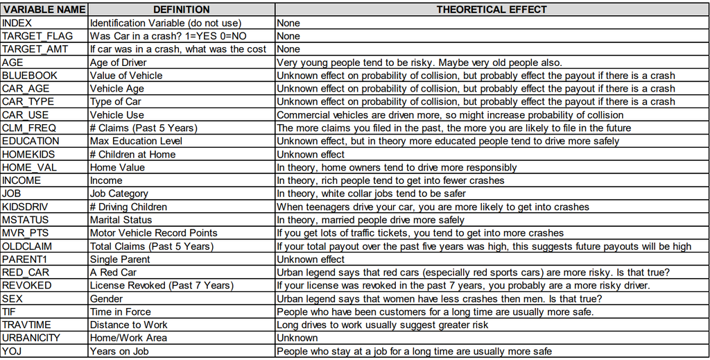

### 1.1 Summary Statistics

Each record in the training dataset also included two response variables. The first response variable, `TARGET_FLAG`, was a boolean where “1” indicated the person was in a car crash. The second response variable, `TARGET_AMT` was a numeric indicating the cost if a car crash occurred; this value was zero if the person did not crash their car.

A sample of the training data appears in the following table:

| INDEX | TARGET_FLAG | TARGET_AMT | KIDSDRIV | AGE | HOMEKIDS | YOJ | INCOME | PARENT1 | HOME_VAL | MSTATUS | SEX | EDUCATION | JOB | TRAVTIME | CAR_USE | BLUEBOOK | TIF | CAR_TYPE | RED_CAR | OLDCLAIM | CLM_FREQ | REVOKED | MVR_PTS | CAR_AGE | URBANICITY |
| --- | --- | --- | --- | --- | --- | --- | --- | --- | --- | --- | --- | --- | --- | --- | --- | --- | --- | --- | --- | --- | --- | --- | --- | --- | --- |
| 1 | 0 | 0 | 0 | 60 | 0 | 11 | $67,349 | No | $0 | z_No | M | PhD | Professional | 14 | Private | $14,230 | 11 | Minivan | yes | $4,461 | 2 | No | 3 | 18 | Highly Urban/ Urban |
| 2 | 0 | 0 | 0 | 43 | 0 | 11 | $91,449 | No | $257,252 | z_No | M | z_High School | z_Blue Collar | 22 | Commercial | $14,940 | 1 | Minivan | yes | $0 | 0 | No | 0 | 1 | Highly Urban/ Urban |
| 4 | 0 | 0 | 0 | 35 | 1 | 10 | $16,039 | No | $124,191 | Yes | z_F | z_High School | Clerical | 5 | Private | $4,010 | 4 | z_SUV | no | $38,690 | 2 | No | 3 | 10 | Highly Urban/ Urban |
| 5 | 0 | 0 | 0 | 51 | 0 | 14 |  | No | $306,251 | Yes | M | &lt;High School | z_Blue Collar | 32 | Private | $15,440 | 7 | Minivan | yes | $0 | 0 | No | 0 | 6 | Highly Urban/ Urban |
| 6 | 0 | 0 | 0 | 50 | 0 |  | $114,986 | No | $243,925 | Yes | z_F | PhD | Doctor | 36 | Private | $18,000 | 1 | z_SUV | no | $19,217 | 2 | Yes | 3 | 17 | Highly Urban/ Urban |
| 7 | 1 | 2946 | 0 | 34 | 1 | 12 | $125,301 | Yes | $0 | z_No | z_F | Bachelors | z_Blue Collar | 46 | Commercial | $17,430 | 1 | Sports Car | no | $0 | 0 | No | 0 | 7 | Highly Urban/ Urban |
| 8 | 0 | 0 | 0 | 54 | 0 |  | $18,755 | No |  | Yes | z_F | &lt;High School | z_Blue Collar | 33 | Private | $8,780 | 1 | z_SUV | no | $0 | 0 | No | 0 | 1 | Highly Urban/ Urban |
| 11 | 1 | 4021 | 1 | 37 | 2 |  | $107,961 | No | $333,680 | Yes | M | Bachelors | z_Blue Collar | 44 | Commercial | $16,970 | 1 | Van | yes | $2,374 | 1 | Yes | 10 | 7 | Highly Urban/ Urban |
| 12 | 1 | 2501 | 0 | 34 | 0 | 10 | $62,978 | No | $0 | z_No | z_F | Bachelors | Clerical | 34 | Private | $11,200 | 1 | z_SUV | no | $0 | 0 | No | 0 | 1 | Highly Urban/ Urban |
| 13 | 0 | 0 | 0 | 50 | 0 | 7 | $106,952 | No | $0 | z_No | M | Bachelors | Professional | 48 | Commercial | $18,510 | 7 | Van | no | $0 | 0 | No | 1 | 17 | z_Highly Rural/ Rural |

[output cut: 15 more lines]

While exploring this data, we made the following observations:

Summary: Training Dataset

| variable | type | missing | complete% | min | max | mean |
| --- | --- | --- | --- | --- | --- | --- |
| INCOME | character | 0 | 1.000 | NA | NA | NA |
| PARENT1 | character | 0 | 1.000 | NA | NA | NA |
| HOME_VAL | character | 0 | 1.000 | NA | NA | NA |
| MSTATUS | character | 0 | 1.000 | NA | NA | NA |
| SEX | character | 0 | 1.000 | NA | NA | NA |
| EDUCATION | character | 0 | 1.000 | NA | NA | NA |
| JOB | character | 0 | 1.000 | NA | NA | NA |
| CAR_USE | character | 0 | 1.000 | NA | NA | NA |
| BLUEBOOK | character | 0 | 1.000 | NA | NA | NA |
| CAR_TYPE | character | 0 | 1.000 | NA | NA | NA |
| RED_CAR | character | 0 | 1.000 | NA | NA | NA |
| OLDCLAIM | character | 0 | 1.000 | NA | NA | NA |
| REVOKED | character | 0 | 1.000 | NA | NA | NA |
| URBANICITY | character | 0 | 1.000 | NA | NA | NA |
| INDEX | numeric | 0 | 1.000 | 1 | 10302.0 | 5151.868 |
| TARGET_FLAG | numeric | 0 | 1.000 | 0 | 1.0 | 0.264 |
| TARGET_AMT | numeric | 0 | 1.000 | 0 | 107586.1 | 1504.325 |
| KIDSDRIV | numeric | 0 | 1.000 | 0 | 4.0 | 0.171 |
| AGE | numeric | 6 | 0.999 | 16 | 81.0 | 44.790 |
| HOMEKIDS | numeric | 0 | 1.000 | 0 | 5.0 | 0.721 |
| YOJ | numeric | 454 | 0.944 | 0 | 23.0 | 10.499 |
| TRAVTIME | numeric | 0 | 1.000 | 5 | 142.0 | 33.486 |
| TIF | numeric | 0 | 1.000 | 1 | 25.0 | 5.351 |
| CLM_FREQ | numeric | 0 | 1.000 | 0 | 5.0 | 0.799 |
| MVR_PTS | numeric | 0 | 1.000 | 0 | 13.0 | 1.696 |
| CAR_AGE | numeric | 510 | 0.938 | -3 | 28.0 | 8.328 |

Summary: Evaluation Dataset

| variable | type | missing | complete% | min | max | mean |
| --- | --- | --- | --- | --- | --- | --- |
| INCOME | character | 0 | 1.000 | NA | NA | NA |
| PARENT1 | character | 0 | 1.000 | NA | NA | NA |
| HOME_VAL | character | 0 | 1.000 | NA | NA | NA |
| MSTATUS | character | 0 | 1.000 | NA | NA | NA |
| SEX | character | 0 | 1.000 | NA | NA | NA |
| EDUCATION | character | 0 | 1.000 | NA | NA | NA |
| JOB | character | 0 | 1.000 | NA | NA | NA |
| CAR_USE | character | 0 | 1.000 | NA | NA | NA |
| BLUEBOOK | character | 0 | 1.000 | NA | NA | NA |
| CAR_TYPE | character | 0 | 1.000 | NA | NA | NA |
| RED_CAR | character | 0 | 1.000 | NA | NA | NA |
| OLDCLAIM | character | 0 | 1.000 | NA | NA | NA |
| REVOKED | character | 0 | 1.000 | NA | NA | NA |
| URBANICITY | character | 0 | 1.000 | NA | NA | NA |
| TARGET_FLAG | logical | 2141 | 0.000 | NA | NA | NA |
| TARGET_AMT | logical | 2141 | 0.000 | NA | NA | NA |
| INDEX | numeric | 0 | 1.000 | 3 | 10300 | 5150.099 |
| KIDSDRIV | numeric | 0 | 1.000 | 0 | 3 | 0.163 |
| AGE | numeric | 1 | 1.000 | 17 | 73 | 45.017 |
| HOMEKIDS | numeric | 0 | 1.000 | 0 | 5 | 0.717 |
| YOJ | numeric | 94 | 0.956 | 0 | 19 | 10.379 |
| TRAVTIME | numeric | 0 | 1.000 | 5 | 105 | 33.152 |
| TIF | numeric | 0 | 1.000 | 1 | 25 | 5.245 |
| CLM_FREQ | numeric | 0 | 1.000 | 0 | 5 | 0.809 |
| MVR_PTS | numeric | 0 | 1.000 | 0 | 12 | 1.766 |
| CAR_AGE | numeric | 129 | 0.940 | 0 | 26 | 8.183 |

### 1.2 Distributions

Many of these distributions for the numeric variables seemed highly skewed and non-normal. As part of our data preparation, we used power transformations to find whether transforming variables to more normal distributions improved our models’ efficacy.

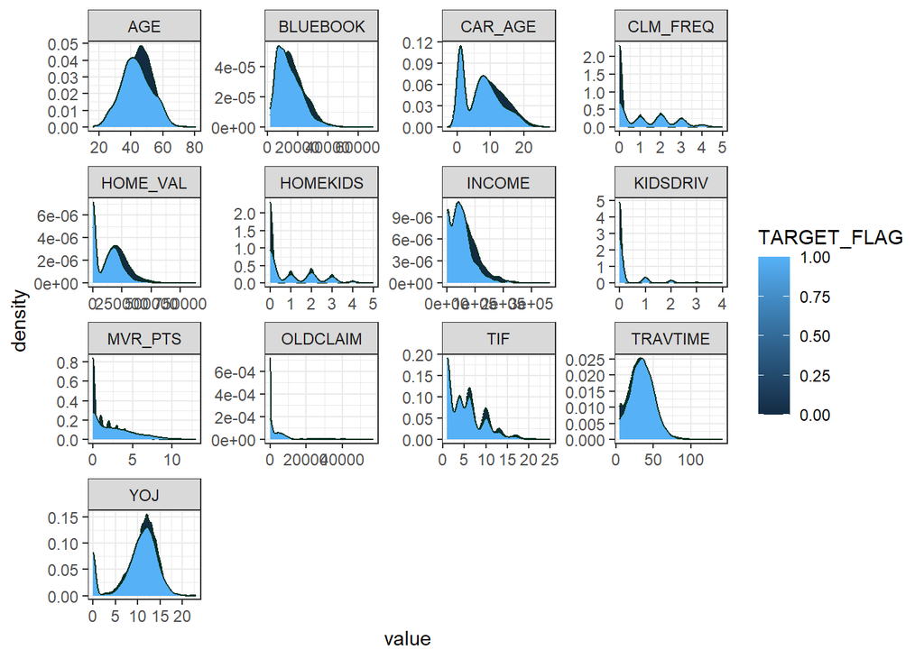

By checking the frequency of the variables with few unique values (`HOMEKIDS`, `KIDSDRIV`, `CLM_FREQ`), we assumed that these variables might perform better if transformed to binary (1 if the value is greater than 0). As demonstrated by the graph below, more than 50% of the data for these variables was 0:

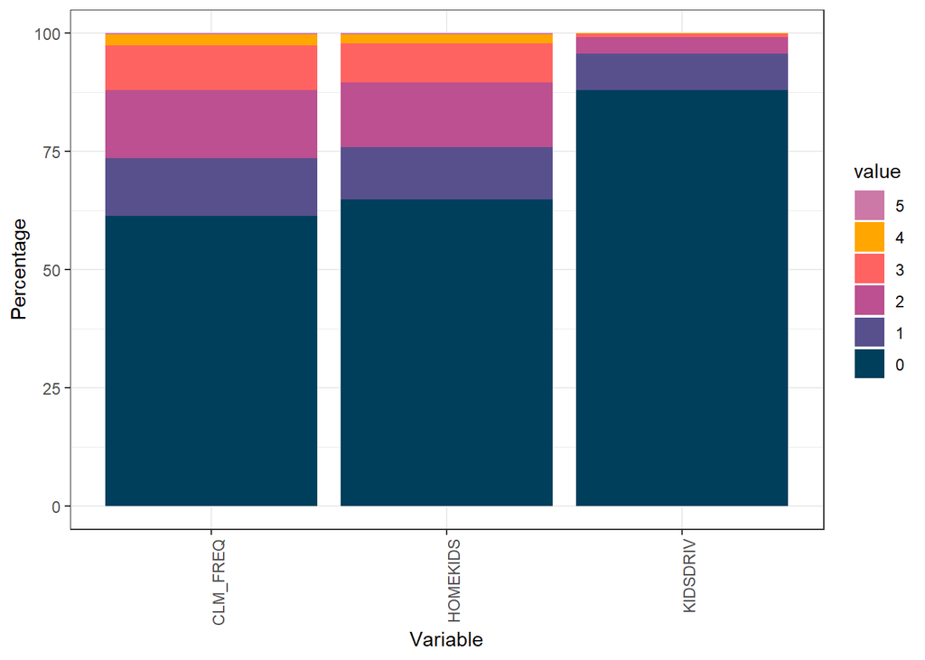

We found that the distribution of factor variables could help determine if transformations should be applied. For example, variable `PARENT1` could become binary, and `CAR_AGE` could be transformed by putting it into buckets.

This analysis also suggested that having more than one parent was correlated with crashes and that High School students, blue-collar employees, SUV cars, and revoked drivers were also more likely to be in a car crash.

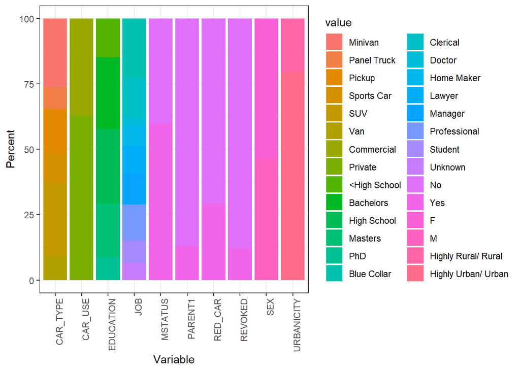

### 1.3 Box Plots

We observed large ranges for `INCOME`, `KIDSDRIV`, and `OLDCLAIM`. `BLUEBOOK`, `INCOME`, `OLDCLAIM`, `TRAVTIME` seemed to have a high frequency of outliers. Additionally, it seemed that people with higher income, car age and home values were less likely to get into a car crash.

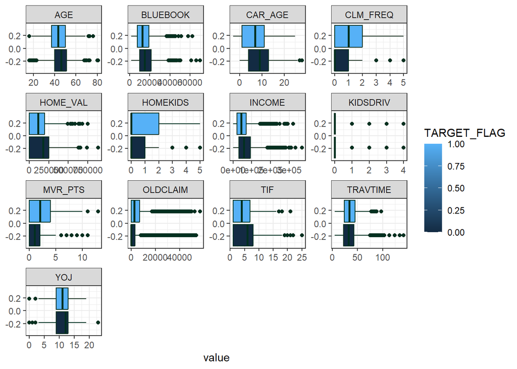

### 1.4 Scatter Plots

Interestingly, none of our predictors appeared to have strong linear relationships to our `TARGET_AMT` response variable, which is a primary assumption of linear regression. This suggested that alternative methods might be more successful in modeling the relationships.

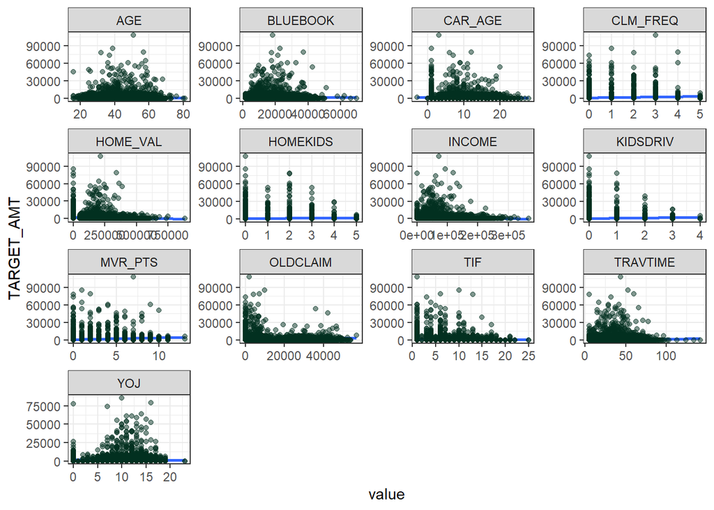

### 1.5 Correlation Matrix

We observed substantial multi-collinearity in our training data, especially between `INCOME` and `HOME_VAL` (+58%), `OLDCLAIM` and `CLAIM_FREQ` (+50%), `KIDSDRIV` and `HOMEKIDS` (+46%), and `AGE` and `HOMEKIDS` (-45%). In building our models, we explored methods for reducing these effects.

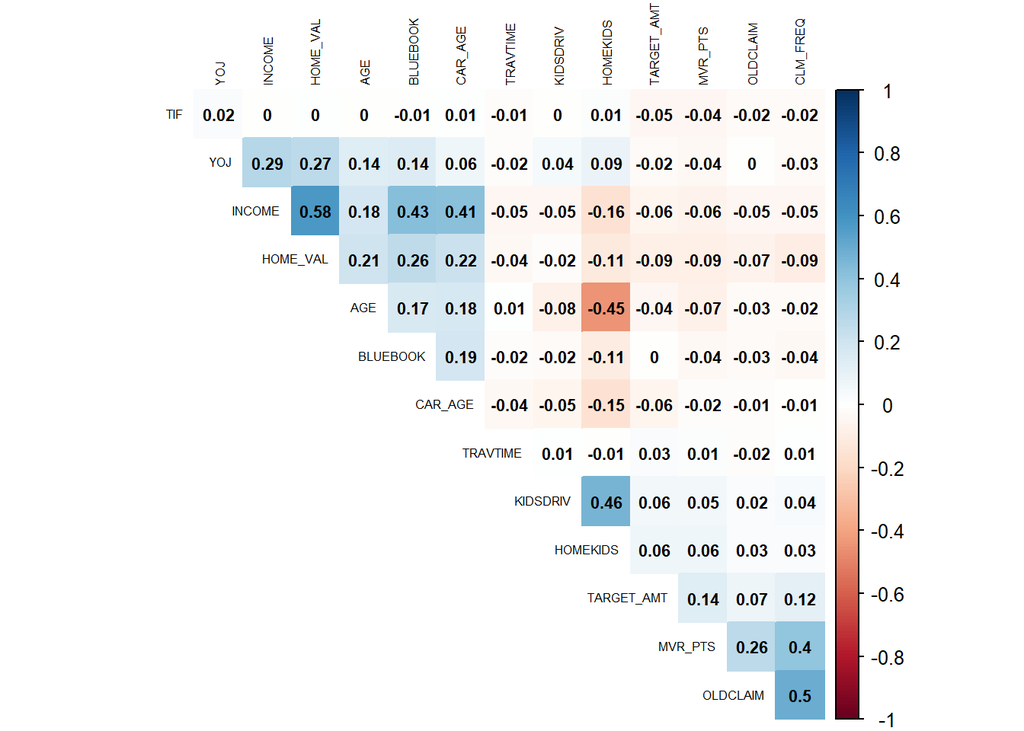

## 2. Data Preparation

### 2.1 Data types

In order to work with our training and evaluation datasets, we needed to first convert some variables to more useful data types:

- Convert currency columns from character to integer: `INCOME`,`HOME_VAL`,`BLUEBOOK` and `OLDCLAIM`.
- Convert character columns to factors: `TARGET_FLAG`, `CAR_TYPE`, `CAR_USE`, `EDUCATION`, `JOB`, `MSTATUS`, `PARENT1`, `RED_CAR`, `REVOKED`, `SEX` and `URBANICITY`.

### 2.2 Transformations, Outliers and Missing Values

Before we went further, we needed to identify and handle any missing, NA or negative data values so we could perform log transformations and regression. We performed these operations on both the training and evaluation datasets.

First, we applied transformations to clean up and align formatting of our variables:

- Dropped the `INDEX` variable.
- Removed “z_” from all character class values (`MSTATUS`, `SEX`, `JOB`, `CAR_TYPE`, `URBANICITY`, `EDUCATION`)
- Removed “$” from the numeric values (`INCOME`, `HOME_VAL`, `BLUEBOOK`, `OLDCLAIM`).
- Updated RED_CAR, replace [no,yes] values with [No, Yes] values.
- Replaced `JOB` blank values with ‘Unknown’.
- Transformed variables `HOMEKIDS`, `KIDSDRIV` to binary; the value is TRUE if the original value is greater than 0.

Next, we manually adjusted two special cases of missing or outlier values.

- In cases where `YOJ` is zero and `INCOME` is NA, we set `INCOME` to zero to avoid imputing new values over legitimate instances of non-employment.
- There was also at least one value of `CAR_AGE` less than zero in the training data - we assumed this was a data collection error and set it to zero (representing a brand-new car.)

We used MICE to impute our remaining variables with missing values - `AGE`, `YOJ`, `CAR_AGE`, `INCOME` and `HOME_VALUE`:

- It was reasonable to assume that relationships exist between these variables (older, more years on the job may correlate with higher income and home value). Taking simple means or medians might have suppressed those features, and MICE provided a better imputation.

To give our models more variables to work with, we engineered some additional features:

- Created bin values for `CAR_AGE`, `HOME_VAL` and `TIF`.
- Created two-level factors for `HOMEKIDS` and `KIDSDRIV`
- Created dummy variables for two-level factors, `MALE`, `MARRIED`, `LIC_REVOKED`, `CAR_RED`, `PRIVATE_USE`, `SINGLE_PARENT` and `URBAN`.

Next we wanted to consider any power transformations for variables with skewed distributions. For example, our numeric response variable `TARGET_AMT` was a good candidate for transformation as its distribution was very highly skewed, and the assumption of normality is required in order to apply linear regression.

- Log transformation applied to variables `TARGET_AMT`, `OLDCLAIM`, `INCOME` to transform their distributions from right-skewed to normally distributed.
- BoxCox transformation applied to variables `BLUEBOOK`, `TRAVTIME`, `TIF`.

A summary and distributions of the final, transformed training dataset appears below (with a temporary numeric variable `CAR_CRASH` to represent the response variable for visualization purposes.). Post-transformation, distributions for many of the variables became closer to normal.

Summary: Transformed Training Dataset

| variable | type | missing | complete% | min | max | mean |
| --- | --- | --- | --- | --- | --- | --- |
| TARGET_FLAG | factor | 0 | 1 | NA | NA | NA |
| KIDSDRIV | factor | 0 | 1 | NA | NA | NA |
| HOMEKIDS | factor | 0 | 1 | NA | NA | NA |
| EDUCATION | factor | 0 | 1 | NA | NA | NA |
| JOB | factor | 0 | 1 | NA | NA | NA |
| CAR_TYPE | factor | 0 | 1 | NA | NA | NA |
| MALE | factor | 0 | 1 | NA | NA | NA |
| MARRIED | factor | 0 | 1 | NA | NA | NA |
| LIC_REVOKED | factor | 0 | 1 | NA | NA | NA |
| CAR_RED | factor | 0 | 1 | NA | NA | NA |
| PRIVATE_USE | factor | 0 | 1 | NA | NA | NA |
| SINGLE_PARENT | factor | 0 | 1 | NA | NA | NA |
| URBAN | factor | 0 | 1 | NA | NA | NA |
| TARGET_AMT | numeric | 0 | 1 | 0.000 | 11.586 | 2.183 |
| AGE | numeric | 0 | 1 | 16.000 | 81.000 | 44.782 |
| YOJ | numeric | 0 | 1 | 0.000 | 23.000 | 10.482 |
| INCOME | numeric | 0 | 1 | 0.000 | 12.813 | 9.927 |
| HOME_VAL | numeric | 0 | 1 | 0.000 | 885282.000 | 154644.846 |
| TRAVTIME | numeric | 0 | 1 | 2.999 | 45.614 | 15.082 |
| BLUEBOOK | numeric | 0 | 1 | 62.211 | 381.011 | 182.315 |
| TIF | numeric | 0 | 1 | 0.000 | 4.702 | 1.634 |
| OLDCLAIM | numeric | 0 | 1 | 0.000 | 10.951 | 3.386 |
| CLM_FREQ | numeric | 0 | 1 | 0.000 | 5.000 | 0.799 |
| MVR_PTS | numeric | 0 | 1 | 0.000 | 13.000 | 1.696 |
| CAR_AGE | numeric | 0 | 1 | 0.000 | 28.000 | 8.340 |
| CAR_AGE_BIN | numeric | 0 | 1 | 1.000 | 4.000 | 2.477 |
| HOME_VAL_BIN | numeric | 0 | 1 | 1.000 | 4.000 | 2.451 |
| TIF_BIN | numeric | 0 | 1 | 1.000 | 4.000 | 2.412 |

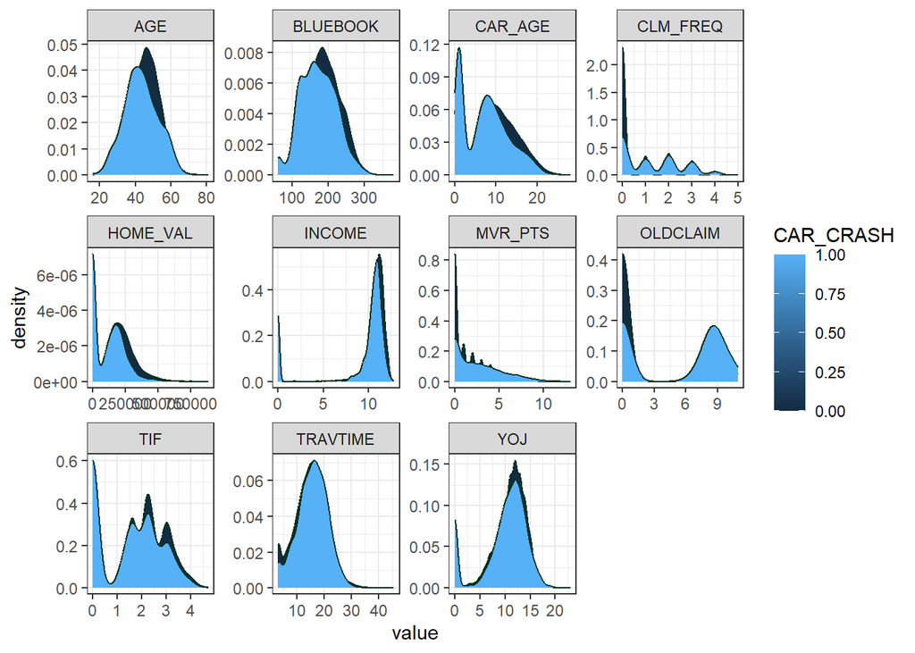

Finally, we split our training data into train (75%) and validation (25%) datasets to evaluate model performance before we proceeded to prediction. Slightly different variations were used depending on each model’s needs and ability to handle binned variables.

## 3. Binary Logistic Regression

We used Binary Logistic Regression to classify our response variable `TARGET_FLAG`, the probability of a car crash for a given observation.

### 3.1 Logistic Model 1 - Original Data

Our first step was to build a logistic regression based on the original training dataset with minimal cleanup and imputation of missing values but without any power transformations for normal distributions.

We applied Stepwise feature selection using stepAIC to reduce multicollinearity and optimize performance.

| Observations | 6121 |
| --- | --- |
| Dependent variable | TARGET_FLAG |
| Type | Generalized linear model |
| Family | binomial |
| Link | logit |

| χ(32) | 1584.51 |
| --- | --- |
| Pseudo-R (Cragg-Uhler) | 0.33 |
| Pseudo-R (McFadden) | 0.22 |
| AIC | 5545.63 |
| BIC | 5767.37 |

|  | Est. | S.E. | z val. | p |
| --- | --- | --- | --- | --- |
| (Intercept) | -2.75 | 0.23 | -11.86 | 0.00 |
| KIDSDRIV1 | 0.63 | 0.11 | 5.75 | 0.00 |
| HOMEKIDS1 | 0.23 | 0.10 | 2.21 | 0.03 |
| INCOME | -0.00 | 0.00 | -3.26 | 0.00 |
| HOME_VAL | -0.00 | 0.00 | -2.79 | 0.01 |
| EDUCATIONBachelors | -0.39 | 0.13 | -3.07 | 0.00 |
| EDUCATIONHigh School | 0.02 | 0.11 | 0.22 | 0.83 |
| EDUCATIONMasters | -0.25 | 0.19 | -1.33 | 0.18 |
| EDUCATIONPhD | 0.00 | 0.23 | 0.02 | 0.99 |
| JOBClerical | 0.11 | 0.12 | 0.93 | 0.35 |
| JOBDoctor | -0.87 | 0.33 | -2.67 | 0.01 |
| JOBHome Maker | -0.20 | 0.17 | -1.16 | 0.25 |
| JOBLawyer | -0.14 | 0.21 | -0.67 | 0.50 |
| JOBManager | -0.92 | 0.16 | -5.69 | 0.00 |
| JOBProfessional | -0.17 | 0.14 | -1.22 | 0.22 |
| JOBStudent | -0.07 | 0.14 | -0.47 | 0.64 |
| JOBUnknown | -0.37 | 0.21 | -1.73 | 0.08 |
| TRAVTIME | 0.01 | 0.00 | 6.63 | 0.00 |
| BLUEBOOK | -0.00 | 0.00 | -4.01 | 0.00 |
| TIF | -0.06 | 0.01 | -6.75 | 0.00 |
| CAR_TYPEPanel Truck | 0.69 | 0.17 | 3.96 | 0.00 |
| CAR_TYPEPickup | 0.59 | 0.11 | 5.12 | 0.00 |
| CAR_TYPESports Car | 0.98 | 0.12 | 7.93 | 0.00 |
| CAR_TYPESUV | 0.73 | 0.10 | 7.35 | 0.00 |
| CAR_TYPEVan | 0.69 | 0.14 | 4.95 | 0.00 |
| OLDCLAIM | -0.00 | 0.00 | -3.32 | 0.00 |
| CLM_FREQ | 0.20 | 0.03 | 5.96 | 0.00 |
| MVR_PTS | 0.11 | 0.02 | 7.24 | 0.00 |
| MARRIED1 | -0.55 | 0.10 | -5.43 | 0.00 |
| LIC_REVOKED1 | 0.90 | 0.11 | 8.55 | 0.00 |
| PRIVATE_USE1 | -0.73 | 0.11 | -6.91 | 0.00 |
| SINGLE_PARENT1 | 0.22 | 0.14 | 1.56 | 0.12 |
| URBAN1 | 2.42 | 0.13 | 18.22 | 0.00 |

Standard errors: MLE

#### Model Performance

The following variables had highly **positive coefficients** in our model, indicating a higher chance to be involved in a car crash:

Positive Coefficients

|  | Est | p |
| --- | --- | --- |
| URBAN1 | 2.422 | 0.000 |
| CAR_TYPESports Car | 0.983 | 0.000 |
| LIC_REVOKED1 | 0.901 | 0.000 |
| CAR_TYPESUV | 0.730 | 0.000 |
| CAR_TYPEPanel Truck | 0.692 | 0.000 |
| CAR_TYPEVan | 0.692 | 0.000 |
| KIDSDRIV1 | 0.632 | 0.000 |
| CAR_TYPEPickup | 0.588 | 0.000 |
| HOMEKIDS1 | 0.228 | 0.027 |

Variables with highly **negative coefficients** indicated a lower chance to be involved in a car crash:

Negative Coefficients

|  | Est | p |
| --- | --- | --- |
| (Intercept) | -2.753 | 0.000 |
| JOBManager | -0.924 | 0.000 |
| JOBDoctor | -0.870 | 0.008 |
| PRIVATE_USE1 | -0.727 | 0.000 |
| MARRIED1 | -0.553 | 0.000 |
| EDUCATIONBachelors | -0.387 | 0.002 |

The `null deviance` of 7064.14 defined how well the target variable could be predicted by a model with only an intercept term.

The `residual deviance` of 5479.63 defined how well the target variable can be predicted by the AIC model that we fit with the predictor variables listed above. The lower the value, the better the model’s predictions of the response variable.

The p-value associated with this `Chi-Square Statistic` was 0 (less than .05), so the model could be useful.

The Akaike information criterion (`AIC`) was 5545.63. The lower the AIC value, the better the model’s ability to fit the data. We used this metric to compare the relative performance of the three Logistic models.

```
## Confusion Matrix and Statistics
##
##           Reference
## Prediction    0    1
##          0 1399  312
##          1  103  226
##
##                Accuracy : 0.7966
##                  95% CI : (0.7784, 0.8138)
##     No Information Rate : 0.7363
##     P-Value [Acc > NIR] : 1.293e-10
##
##                   Kappa : 0.4016
##
##  Mcnemar's Test P-Value : < 2.2e-16
##
##             Sensitivity : 0.4201
##             Specificity : 0.9314
##          Pos Pred Value : 0.6869
##          Neg Pred Value : 0.8177
##              Prevalence : 0.2637
##          Detection Rate : 0.1108
##    Detection Prevalence : 0.1613
##       Balanced Accuracy : 0.6757
##
##        'Positive' Class : 1
##
```

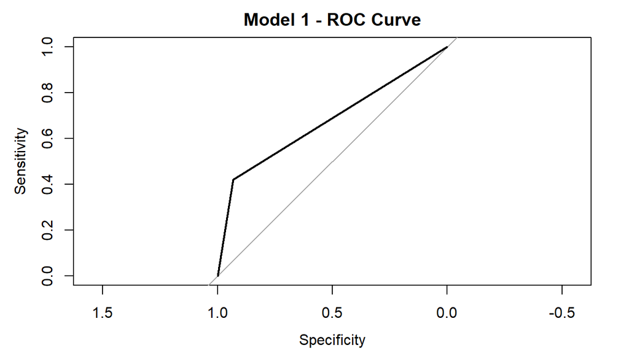

#### Model Assumptions

We evaluated the modeling assumptions using standard diagnostic plots, marginal model plots, and a Variance Inflation Factor (VIF) to assess collinearity.

The resulting plot 1 below (predicted values vs. residuals) helped identify over- or under-predicting. It seems that we experienced under-fitting at lower predicted values, with the predicted proportions being larger than the observed proportions.

On the other hand, we saw over-fitting for a couple of predictor patterns at higher predicted values. The labeled points refer to rows in our data.

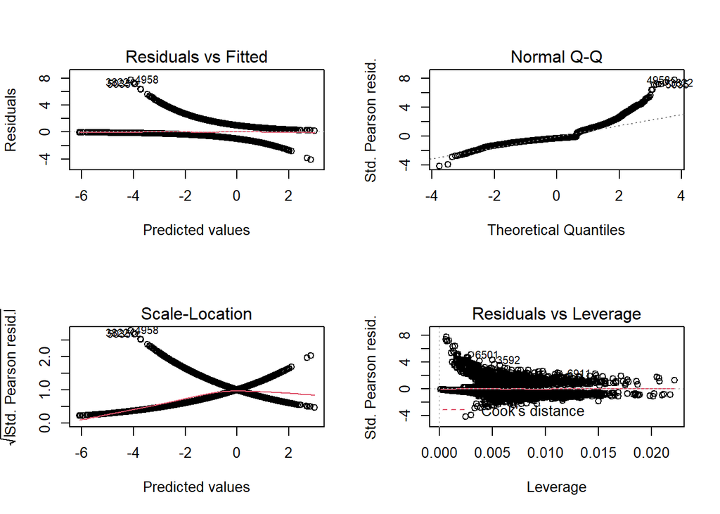

The Standardized Residuals plot seems to show constant variance, but there are some outliers.

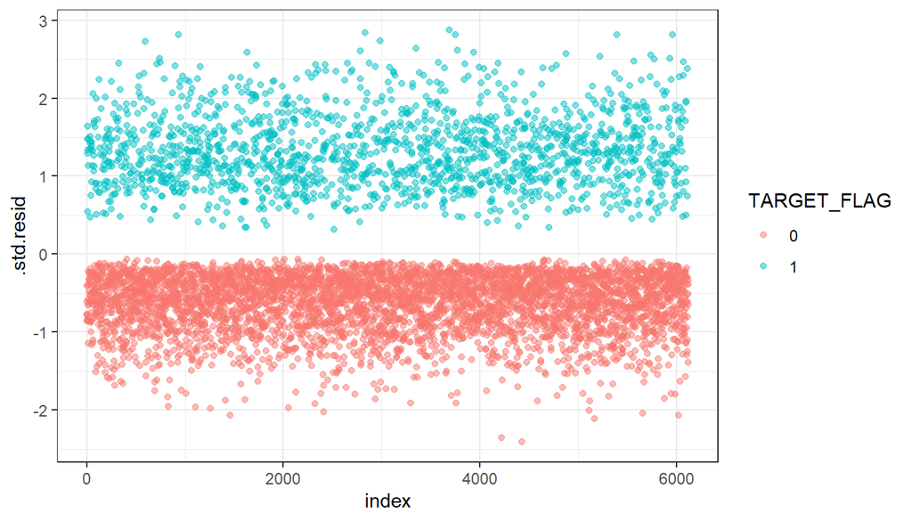

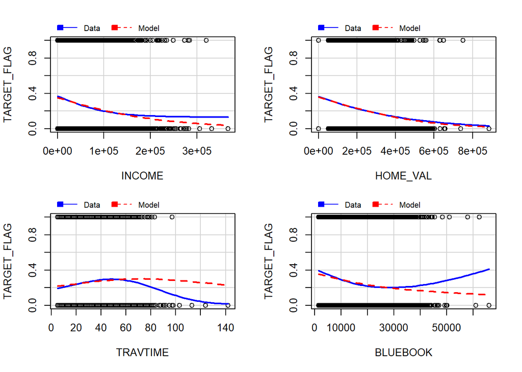

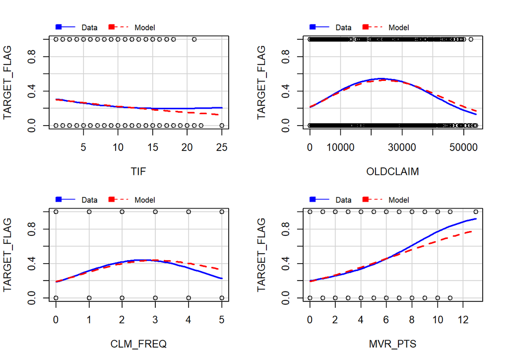

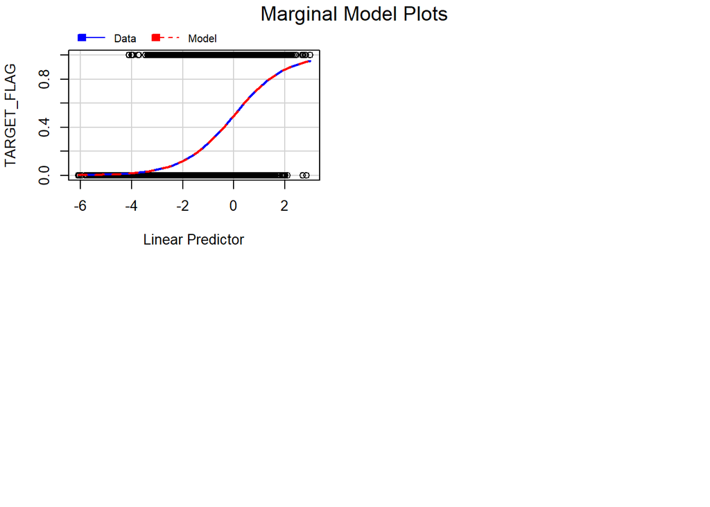

All variables had a VIF less than 5 except `JOB` and `EDUCATION`, indicating that multi-collinearity may still have been a problem for this model.

Variance Inflation Factor

|  | GVIF | df | adj |
| --- | --- | --- | --- |
| JOB | 19.083 | 8 | 1.202 |
| EDUCATION | 8.347 | 4 | 1.304 |
| INCOME | 2.828 | 1 | 1.682 |
| CAR_TYPE | 2.624 | 5 | 1.101 |
| PRIVATE_USE | 2.418 | 1 | 1.555 |
| SINGLE_PARENT | 2.345 | 1 | 1.531 |
| MARRIED | 2.296 | 1 | 1.515 |
| HOMEKIDS | 2.276 | 1 | 1.509 |
| HOME_VAL | 2.032 | 1 | 1.425 |
| BLUEBOOK | 1.796 | 1 | 1.340 |
| OLDCLAIM | 1.641 | 1 | 1.281 |
| CLM_FREQ | 1.468 | 1 | 1.211 |
| KIDSDRIV | 1.363 | 1 | 1.168 |
| LIC_REVOKED | 1.317 | 1 | 1.148 |
| MVR_PTS | 1.159 | 1 | 1.076 |
| URBAN | 1.134 | 1 | 1.065 |
| TRAVTIME | 1.038 | 1 | 1.019 |
| TIF | 1.011 | 1 | 1.006 |

### 3.2 Logistic Model 2 - Transformed

Next, we built a Logistic regression based on the original training dataset with cleanup and imputation of missing values, plus power transformations for normal distributions.

We applied Stepwise feature selection using stepAIC to reduce multicollinearity and optimize performance.

| Observations | 6121 |
| --- | --- |
| Dependent variable | TARGET_FLAG |
| Type | Generalized linear model |
| Family | binomial |
| Link | logit |

| χ(33) | 1631.73 |
| --- | --- |
| Pseudo-R (Cragg-Uhler) | 0.34 |
| Pseudo-R (McFadden) | 0.23 |
| AIC | 5500.41 |
| BIC | 5728.87 |

|  | Est. | S.E. | z val. | p |
| --- | --- | --- | --- | --- |
| (Intercept) | -1.49 | 0.32 | -4.68 | 0.00 |
| KIDSDRIV1 | 0.61 | 0.11 | 5.51 | 0.00 |
| HOMEKIDS1 | 0.16 | 0.10 | 1.58 | 0.11 |
| YOJ | 0.03 | 0.01 | 2.32 | 0.02 |
| INCOME | -0.10 | 0.02 | -4.70 | 0.00 |
| EDUCATIONBachelors | -0.39 | 0.13 | -3.12 | 0.00 |
| EDUCATIONHigh School | 0.01 | 0.11 | 0.10 | 0.92 |
| EDUCATIONMasters | -0.32 | 0.19 | -1.71 | 0.09 |
| EDUCATIONPhD | -0.38 | 0.22 | -1.70 | 0.09 |
| JOBClerical | -0.03 | 0.12 | -0.27 | 0.79 |
| JOBDoctor | -0.97 | 0.34 | -2.83 | 0.00 |
| JOBHome Maker | -0.38 | 0.19 | -2.00 | 0.05 |
| JOBLawyer | -0.29 | 0.22 | -1.32 | 0.19 |
| JOBManager | -1.00 | 0.16 | -6.12 | 0.00 |
| JOBProfessional | -0.26 | 0.14 | -1.86 | 0.06 |
| JOBStudent | -0.47 | 0.17 | -2.78 | 0.01 |
| JOBUnknown | -0.31 | 0.21 | -1.47 | 0.14 |
| TRAVTIME | 0.04 | 0.01 | 7.08 | 0.00 |
| BLUEBOOK | -0.00 | 0.00 | -4.83 | 0.00 |
| CAR_TYPEPanel Truck | 0.57 | 0.17 | 3.34 | 0.00 |
| CAR_TYPEPickup | 0.55 | 0.12 | 4.71 | 0.00 |
| CAR_TYPESports Car | 0.97 | 0.13 | 7.66 | 0.00 |
| CAR_TYPESUV | 0.74 | 0.10 | 7.42 | 0.00 |
| CAR_TYPEVan | 0.70 | 0.14 | 5.00 | 0.00 |
| OLDCLAIM | 0.02 | 0.01 | 1.73 | 0.08 |
| CLM_FREQ | 0.08 | 0.05 | 1.50 | 0.13 |
| MVR_PTS | 0.10 | 0.02 | 6.24 | 0.00 |
| MARRIED1 | -0.51 | 0.10 | -5.10 | 0.00 |
| LIC_REVOKED1 | 0.67 | 0.09 | 7.08 | 0.00 |
| PRIVATE_USE1 | -0.71 | 0.11 | -6.66 | 0.00 |
| SINGLE_PARENT1 | 0.28 | 0.14 | 2.01 | 0.04 |
| URBAN1 | 2.48 | 0.13 | 18.61 | 0.00 |
| HOME_VAL_BIN | -0.17 | 0.04 | -4.17 | 0.00 |
| TIF_BIN | -0.22 | 0.03 | -7.50 | 0.00 |

Standard errors: MLE

#### Model Performance

The following variables had highly **positive coefficients** in our model, indicating a much higher chance to be involved in a car crash:

Positive Coefficients

|  | Est. | p |
| --- | --- | --- |
| URBAN1 | 2.478 | 0.000 |
| CAR_TYPESports Car | 0.973 | 0.000 |
| CAR_TYPESUV | 0.742 | 0.000 |
| CAR_TYPEVan | 0.701 | 0.000 |
| LIC_REVOKED1 | 0.666 | 0.000 |
| KIDSDRIV1 | 0.610 | 0.000 |
| CAR_TYPEPanel Truck | 0.566 | 0.001 |
| CAR_TYPEPickup | 0.551 | 0.000 |
| SINGLE_PARENT1 | 0.283 | 0.044 |

Variables with highly **negative coefficients** indicated a lower chance to be involved in a car crash:

Negative Coefficients

|  | Est. | p |
| --- | --- | --- |
| (Intercept) | -1.488 | 0.000 |
| JOBManager | -1.002 | 0.000 |
| JOBDoctor | -0.970 | 0.005 |
| PRIVATE_USE1 | -0.705 | 0.000 |
| MARRIED1 | -0.515 | 0.000 |
| JOBStudent | -0.469 | 0.006 |
| EDUCATIONBachelors | -0.391 | 0.002 |
| JOBHome Maker | -0.382 | 0.046 |
| TIF_BIN | -0.220 | 0.000 |

The results were similar to Logistic Model 1.

The `null deviance` was 7064.14, and the `residual deviance` was 5432.41.

The p-value associated with the `Chi-Square Statistic` was 0 (less than .05), so the model could be useful.

The Akaike information criterion (`AIC`) was 5500.41.

The `Accuracy` was 0.794, `Sensitivity` was 0.43, and `Specificity` was 0.92.

```
## Confusion Matrix and Statistics
##
##           Reference
## Prediction    0    1
##          0 1389  308
##          1  113  230
##
##                Accuracy : 0.7936
##                  95% CI : (0.7754, 0.811)
##     No Information Rate : 0.7363
##     P-Value [Acc > NIR] : 9.692e-10
##
##                   Kappa : 0.3986
##
##  Mcnemar's Test P-Value : < 2.2e-16
##
##             Sensitivity : 0.4275
##             Specificity : 0.9248
##          Pos Pred Value : 0.6706
##          Neg Pred Value : 0.8185
##              Prevalence : 0.2637
##          Detection Rate : 0.1127
##    Detection Prevalence : 0.1681
##       Balanced Accuracy : 0.6761
##
##        'Positive' Class : 1
##
```

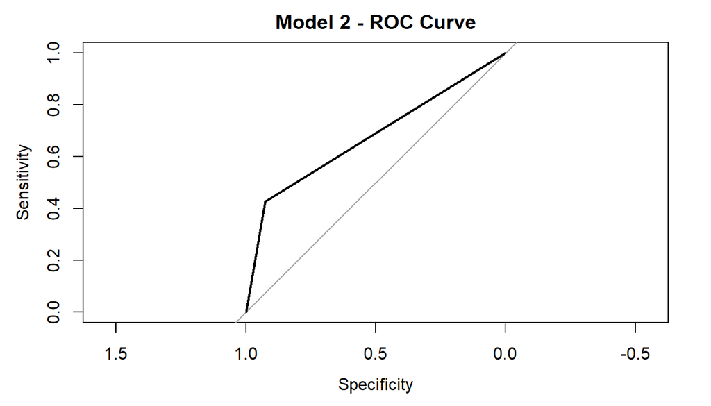

#### Model Assumptions

The resulting plots were similar to Model 1 with under-fitting at lower predicted values (predicted proportions being larger than the observed proportions) and over-fitting at higher predicted values.

Examining the Standardized Pearson Residuals plot, the model seemed good until the middle range but there were extremes on the left. Some normality of the residuals for binomial logistic regression were just evidence of a decent-fitting model.

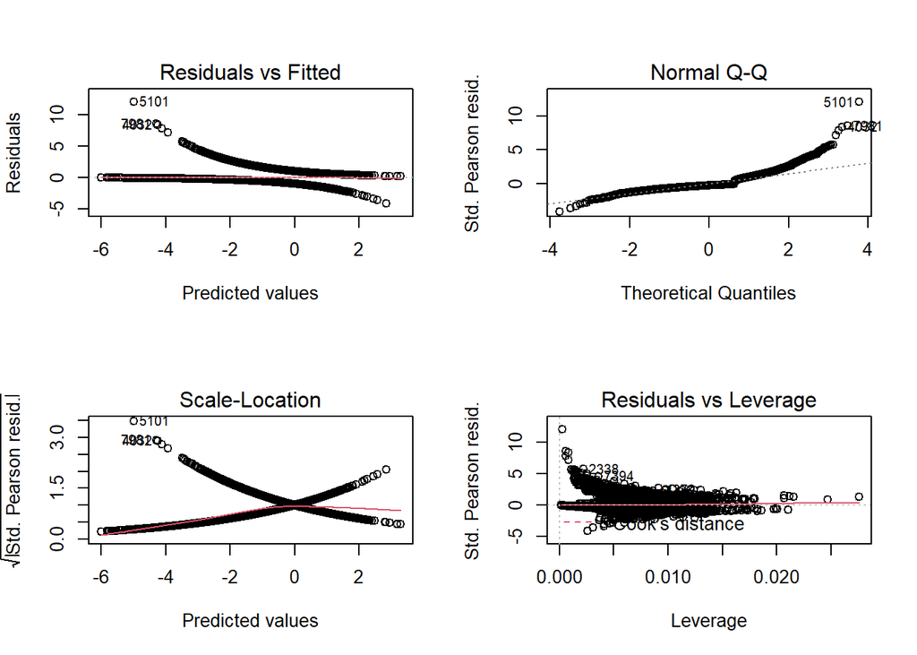

The Standardized Residuals plot seemed to have a constant variance, though there are some outliers.

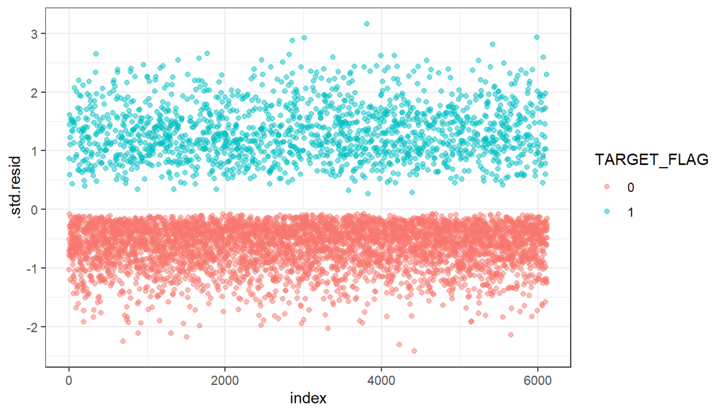

The marginal model plots showed reasonable agreement across the two sets of fits indicating this was a valid model. The plots looked better than for Model 1, with data and model values matching almost everywhere.

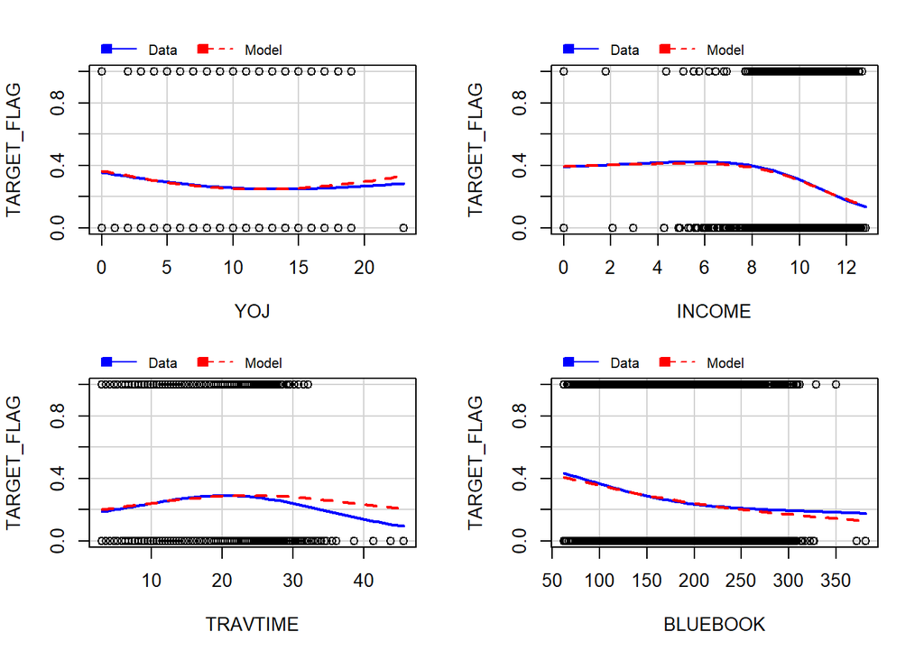

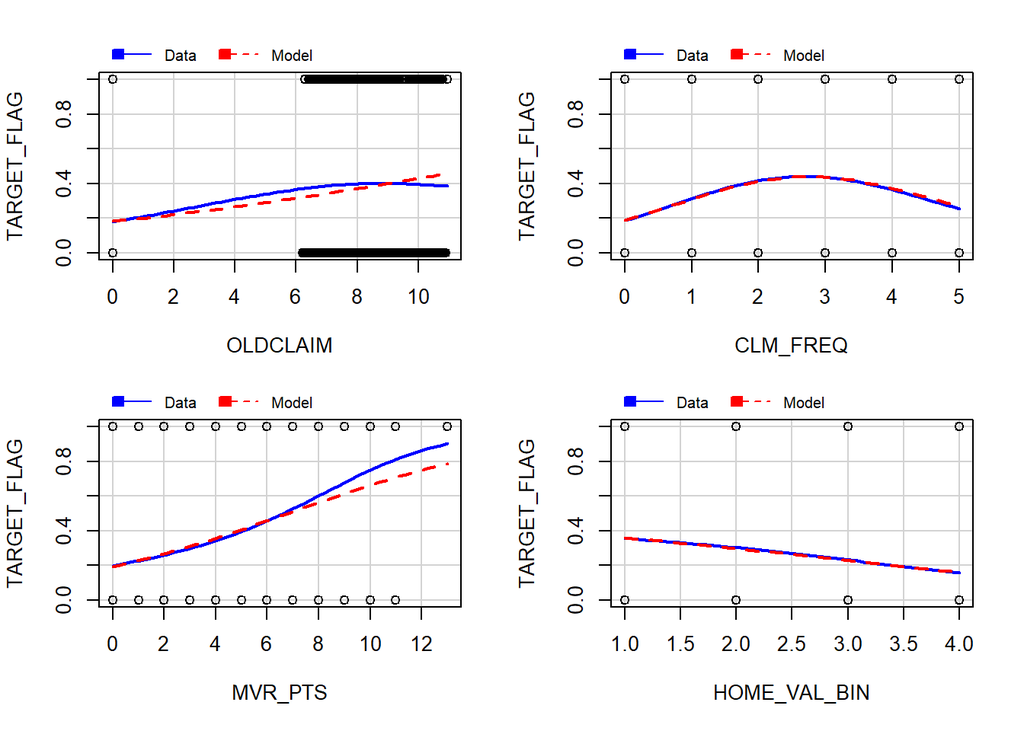

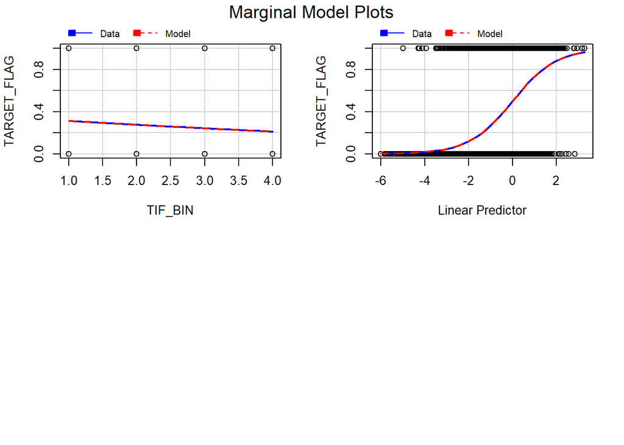

All variables had a VIF less than 5 besides `JOB` and `EDUCATION`, indicating multi-collinearity may still have been a problem for the model.

Variance Inflation Factor

|  | GVIF | df | adj |
| --- | --- | --- | --- |
| JOB | 30.632 | 8 | 1.238 |
| EDUCATION | 7.314 | 4 | 1.282 |
| INCOME | 4.124 | 1 | 2.031 |
| OLDCLAIM | 3.598 | 1 | 1.897 |
| CLM_FREQ | 3.365 | 1 | 1.834 |
| CAR_TYPE | 2.522 | 5 | 1.097 |
| PRIVATE_USE | 2.429 | 1 | 1.559 |
| YOJ | 2.376 | 1 | 1.541 |
| SINGLE_PARENT | 2.294 | 1 | 1.515 |
| HOMEKIDS | 2.255 | 1 | 1.502 |
| MARRIED | 2.225 | 1 | 1.492 |
| HOME_VAL_BIN | 1.776 | 1 | 1.333 |
| BLUEBOOK | 1.658 | 1 | 1.287 |
| KIDSDRIV | 1.355 | 1 | 1.164 |
| MVR_PTS | 1.235 | 1 | 1.111 |
| URBAN | 1.146 | 1 | 1.071 |
| TRAVTIME | 1.037 | 1 | 1.019 |
| LIC_REVOKED | 1.029 | 1 | 1.015 |
| TIF_BIN | 1.012 | 1 | 1.006 |

### 3.3 Logistic Model 3 - Lasso

Lasso Regression was a good candidate for this dataset since we were dealing with a large number of complex variables. Lasso helps identify the most important variables and reduces the model’s complexity.

The cv.glmnet() function was also used for our Logistic regression model. K-fold cross-validation was performed with variable selection using Lasso regularization. The following attribute settings were selected:

```
##
## Call:  cv.glmnet(x = X, y = Y, nfolds = 5, family = "binomial", link = "logit",      standardize = TRUE, alpha = 1)
##
## Measure: Binomial Deviance
##
##       Lambda Index Measure       SE Nonzero
## min 0.001145    49  0.9092 0.004394      34
## 1se 0.004623    34  0.9133 0.003342      28
```

#### Model Performance

We explored model performance by extracting coefficients for values of `lambda.min` and `lambda.1se`.

- The coefficients extracted using `lambda.min` minimized the mean cross-validated error. The resulting model included 35 non-zero coefficients and had an AIC of -1514, the lowest AIC and the highest-performing model of the two.
- The coefficients extracted using `lambda.1se` produced the most regularized model (cross-validated error was within one standard error of the minimum). The resulting model included 29 non-zero coefficients and had an AIC of -1485.

We used the coefficients extracted using `lambda.min` in our predictions.

```
##          True
## Predicted    0   1 Total
##     0     1400 314  1714
##     1      102 224   326
##     Total 1502 538  2040
##
##  Percent Correct:  0.7961
```

```
## $deviance
## lambda.min
##  0.8955268
## attr(,"measure")
## [1] "Binomial Deviance"
##
## $class
## lambda.min
##  0.2127103
## attr(,"measure")
## [1] "Misclassification Error"
##
## $auc
## [1] 0.8128818
## attr(,"measure")
## [1] "AUC"
##
## $mse
## lambda.min
##  0.2912111
## attr(,"measure")
## [1] "Mean-Squared Error"
##
## $mae
## lambda.min
##  0.5876878
## attr(,"measure")
## [1] "Mean Absolute Error"
```

```
## $AICc
## [1] -1514.227
##
## $BIC
## [1] -1286.156
```

```
## $AICc
## [1] -1485.047
##
## $BIC
## [1] -1297.168
```

#### Model Assumptions

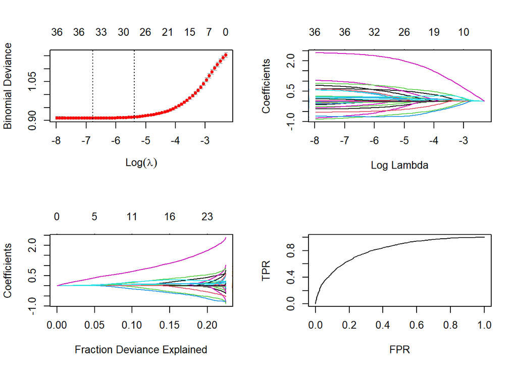

- `URBAN1` - working or living in an urban neighborhood increased the likelihood associated with a crash
- `CAR_TYPE Sports Car` - sports cars increased the likelihood
- `LIC_REVOKED1` - a history of having a revoked license increased the likelihood
- `JOB Manager` - being a manager reduced the likelihood
- `PRIVATE_USE1` - using a car for private activities reduced the likelihood

The `AGE`, `JOB Student` and `CAR_RED1` predictor variables dropped out of the final model.

Model Coefficients

|  | Est |
| --- | --- |
| URBAN1 | 2.343 |
| CAR_TYPESports Car | 0.943 |
| LIC_REVOKED1 | 0.851 |
| CAR_TYPESUV | 0.706 |
| KIDSDRIV1 | 0.609 |
| CAR_TYPEVan | 0.538 |
| CAR_TYPEPickup | 0.491 |
| CAR_TYPEPanel Truck | 0.484 |
| HOMEKIDS1 | 0.231 |
| SINGLE_PARENT1 | 0.215 |
| CLM_FREQ | 0.186 |
| JOBClerical | 0.169 |
| MVR_PTS | 0.110 |
| MALE1 | 0.084 |
| EDUCATIONHigh School | 0.028 |
| TRAVTIME | 0.014 |
| AGE | 0.000 |
| JOBStudent | 0.000 |
| CAR_RED1 | 0.000 |
| HOME_VAL | 0.000 |
| INCOME | 0.000 |
| OLDCLAIM | 0.000 |
| BLUEBOOK | 0.000 |
| CAR_AGE | -0.002 |
| YOJ | -0.004 |
| JOBLawyer | -0.011 |
| EDUCATIONPhD | -0.020 |
| TIF | -0.054 |
| JOBProfessional | -0.075 |
| JOBHome Maker | -0.081 |
| JOBUnknown | -0.226 |
| EDUCATIONMasters | -0.262 |
| EDUCATIONBachelors | -0.358 |
| MARRIED1 | -0.521 |
| JOBDoctor | -0.693 |
| PRIVATE_USE1 | -0.758 |
| JOBManager | -0.807 |
| (Intercept) | -2.715 |

The Lasso regression helped solve the multi-collinearity issue by selecting the variables with the largest coefficients and scaling the rest to very small values.

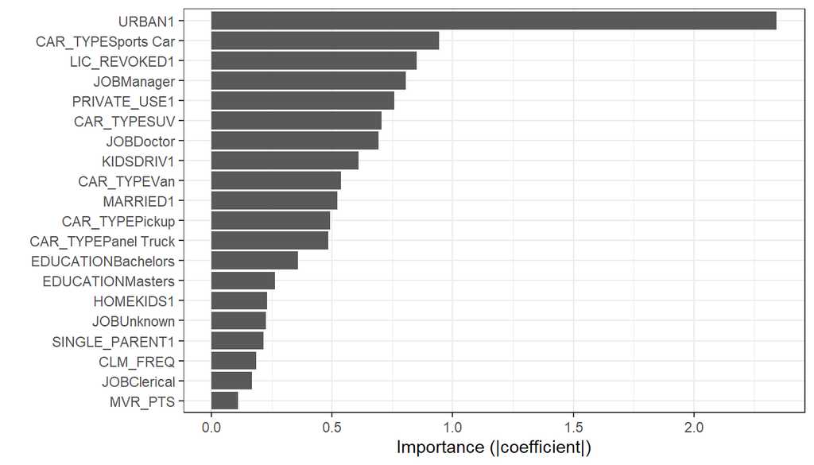

[figure not shown]

### 3.4 Model selection

To choose among our three models for prediction, we focused on performance only - comparing ROC curves, performance statistics and confusion matrices.

The models did not differ in terms of variables selected as predictors. Models 1 and 2 were similar as we used Stepwise selection (stepAIC) for both, although the application of BoxCox transformations did lower the AIC result for Model 2.

Even though Model 3’s Accuracy was lower than Model 1, its AIC and Deviance were by far the lowest of the three, so we chose it for predictions.

Logistic Model Comparison

| Model | Accuracy | Classification error rate | F1 | Deviance | R2 | Sensitivity | Specificity | Precision | AUC | AIC |
| --- | --- | --- | --- | --- | --- | --- | --- | --- | --- | --- |
| Model #1: Original data | 0.797 | 0.203 | 0.521 | 5479.625 | 0.224 | 0.420 | 0.931 | 0.687 | 0.6757496 | 5545.625 |
| Model #2: Transformed data | 0.794 | 0.206 | 0.522 | 5432.408 | 0.231 | 0.428 | 0.925 | 0.671 | 0.6761381 | 5500.408 |
| Model #3: Lasso | 0.796 | 0.204 | 0.519 | 0.893 | NA | 0.416 | 0.932 | 0.687 | 0.8145843 | -1514.227 |

## 4. Multiple Linear Regression

We used Multiple Linear Regression to model the `TARGET_AMT` response variable, the estimated cost of a crash for a given observation. We only included observations where `TARGET_FLAG=1` since if there was no crash, then no costs were incurred.

### 4.1 Linear Model 1 - Original Data

Our first step was to build a linear regression based on the original training dataset with minimal cleanup and imputation of missing values but without any power transformations for normal distributions.

We applied Stepwise feature selection using stepAIC to reduce multicollinearity and optimize performance.

With stepAIC, we selected variables that contributed the most performance to our model. Based on the results of the function, we included `BLUEBOOK`, `MVR_PTS`, `MALE1`, and `LIC_REVOKED1`.

| Observations | 1617 |
| --- | --- |
| Dependent variable | TARGET_AMT |
| Type | OLS linear regression |

| F(4,1612) | 9.1841 |
| --- | --- |
| R | 0.0223 |
| Adj. R | 0.0199 |

|  | Est. | S.E. | t val. | p |
| --- | --- | --- | --- | --- |
| (Intercept) | 3502.9583 | 479.1917 | 7.3101 | 0.0000 |
| BLUEBOOK | 0.1278 | 0.0241 | 5.2951 | 0.0000 |
| MVR_PTS | 126.7957 | 76.4841 | 1.6578 | 0.0976 |
| MALE1 | 634.2666 | 400.9366 | 1.5820 | 0.1139 |
| LIC_REVOKED1 | -704.6944 | 489.8423 | -1.4386 | 0.1505 |

Standard errors: OLS

#### Model Performance

The adjusted R2 indicated that only 2% of the variance in the response variable could be explained by the predictor variables.

Positive coefficients indicated an increase in the cost of a crash. In this model Males, cars with high Bluebook values, and drivers with a high number of Motor Vehicle Points tended to have more expensive crashes.

Similarly, negative coefficients indicated less-expensive crashes. In this model, drivers with License Revocations tended to have less expensive crashes.

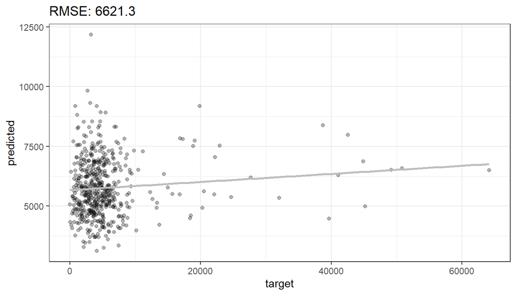

#### Model Assumptions

We evaluated the linear modeling assumptions using standard diagnostic plots, and Variance Inflation Factor (VIF) to assess collinearity.

The variables included in our model had a VIF of 1, indicating the variables were not correlated.

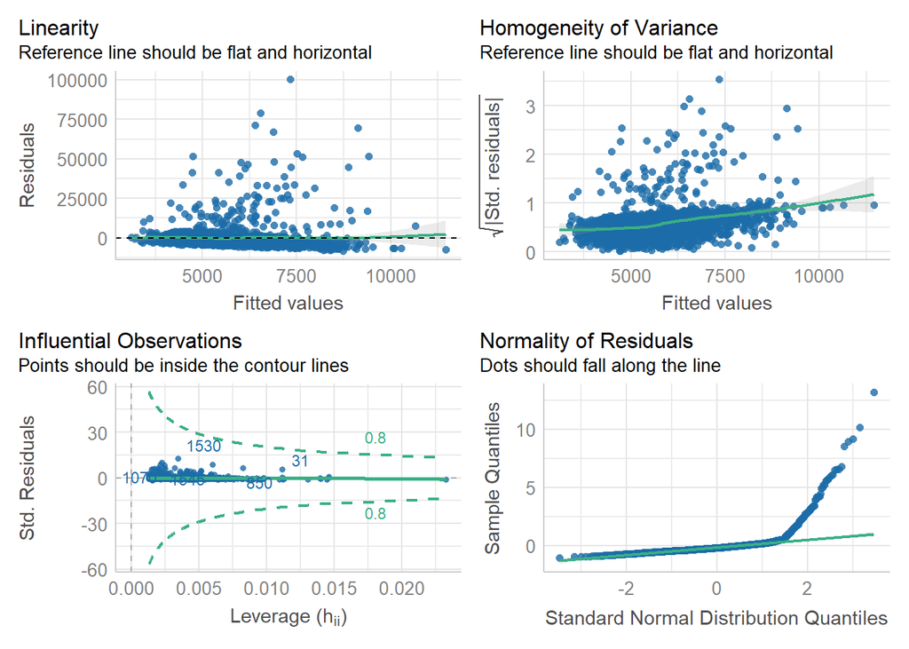

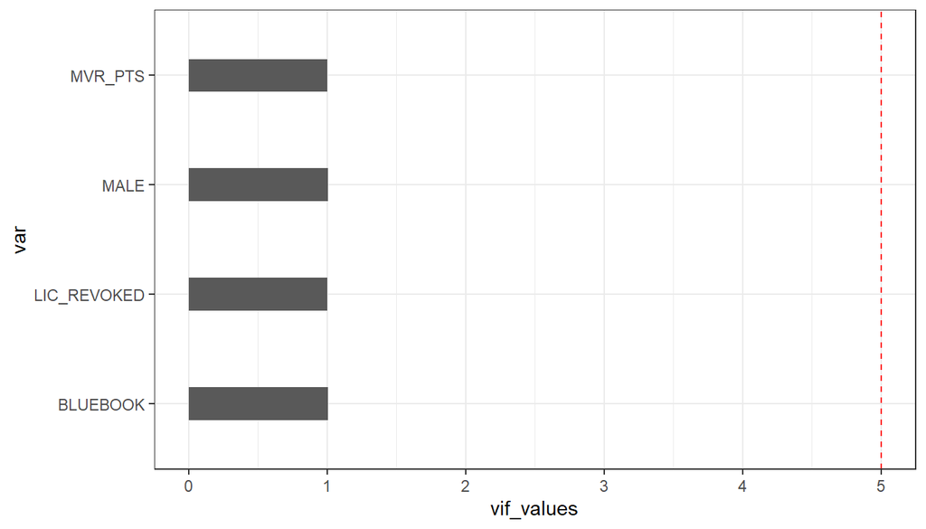

### 4.2 Linear Model 2 - Transformed

Next, we built a linear model based on the training dataset with cleanup and imputation of missing values, plus power transformations for normal distributions.

We applied Stepwise feature selection using stepAIC to reduce multicollinearity and optimize performance.

Based on the the results of the function, we included `BLUEBOOK`, `MVR_PTS`, `CLM_FREQ`, `SINGLE_PARENT1` and `EDUCATION`.

| Observations | 1617 |
| --- | --- |
| Dependent variable | TARGET_AMT |
| Type | OLS linear regression |

| F(8,1608) | 4.8536 |
| --- | --- |
| R | 0.0236 |
| Adj. R | 0.0187 |

|  | Est. | S.E. | t val. | p |
| --- | --- | --- | --- | --- |
| (Intercept) | 7.9712 | 0.0859 | 92.7957 | 0.0000 |
| EDUCATIONBachelors | -0.0812 | 0.0622 | -1.3055 | 0.1919 |
| EDUCATIONHigh School | -0.0240 | 0.0570 | -0.4216 | 0.6734 |
| EDUCATIONMasters | 0.0562 | 0.0707 | 0.7961 | 0.4261 |
| EDUCATIONPhD | 0.1449 | 0.0972 | 1.4897 | 0.1365 |
| BLUEBOOK | 0.0017 | 0.0004 | 3.9508 | 0.0001 |
| CLM_FREQ | -0.0321 | 0.0169 | -1.8999 | 0.0576 |
| MVR_PTS | 0.0197 | 0.0080 | 2.4573 | 0.0141 |
| SINGLE_PARENT1 | 0.0942 | 0.0484 | 1.9443 | 0.0520 |

Standard errors: OLS

#### Model Performance

The F-statistic was `4.85`, and out of the 24 variables, 2 had statistically significant p-values.

The Adjusted R-Squared of 0.02 was similar to Model 1, only explaining about 2% of the total variance in the response variable `TARGET_AMT`.

The RMSE was 0.8 which was a great improvement over Model 1.

Positive coefficients indicated an increase in the cost of a crash. In this model Single parents, people with Masters and PhD degrees, and drivers with a high number of Motor Vehicle Points tended to have more expensive crashes.

Similarly, negative coefficients indicate less-expensive crashes. In this model, drivers with High School and Bachelor’s degrees, and drivers with high numbers of previous claims tended to have less expensive crashes.

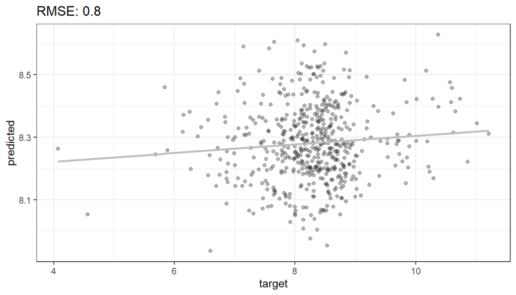

#### Model Assumptions

An examination of the residuals indicated most of the key assumptions for linear regression wer met - the Residuals vs Fitted plot showed a more constant variability of the residuals, and the Q-Q plot indicated a much better level of normality compaed to Model 1.

The variables included in our model had a VIF of 1 (or slightly above), indicating the variables were not correlated, for the most part.

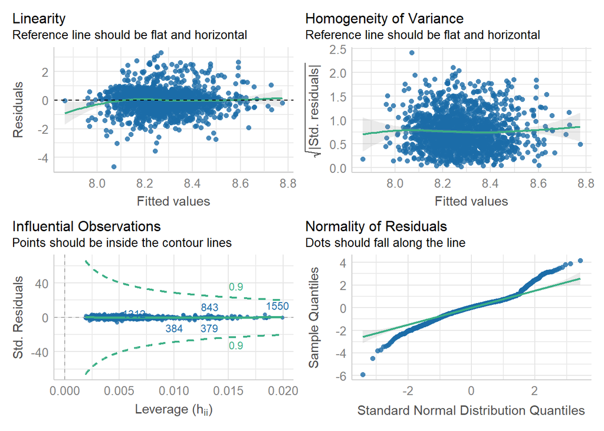

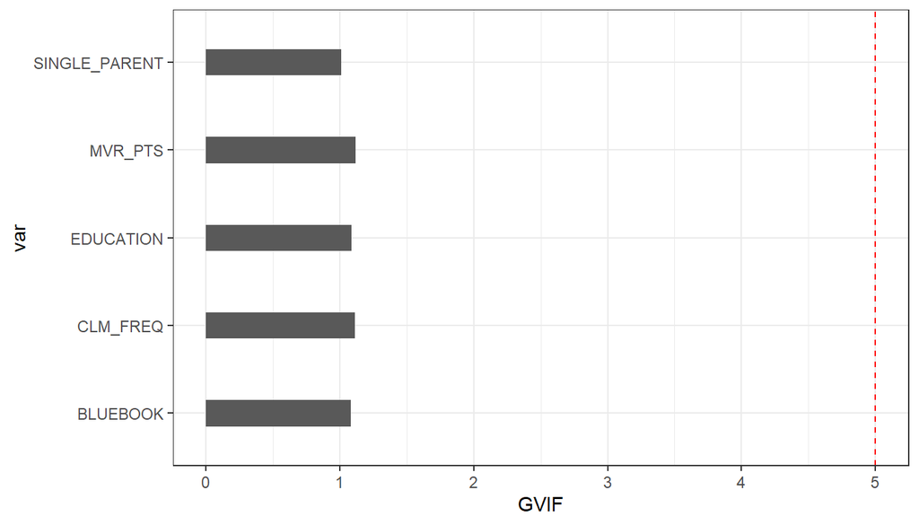

### 4.3 Linear Model 3 - Lasso

The `cv.glmnet()` function was used to perform k-fold cross-validation with variable selection using lasso regularization. The following attribute settings were selected for the model:

- type.measure = “mse” - The type.measure is set to minimize the Mean Squared Error for the model.
- nfold = 10 - Given the size of the dataset we defaulted to 10-fold cross-validation.
- family = gaussian - For Linear Regression
- alpha = 1 - The alpha value of 1 sets the variable shrinkage method to lasso.
- standardize = TRUE - Finally, we explicitly set the standardization attribute to TRUE; this will normalize the prediction variables around a mean of zero and a standard deviation of one before modeling.

The resulting model was explored by extracting coefficients at two different values for lambda, lambda.min and lambda.1se respectively.

The coefficients extracted using lambda.min minimized the mean cross-validated error. The resulting model included 1 non-zero coefficient and has an AIC of -1584023783.

The coefficients extracted using lambda.1se did not produce a valid model - all variables dropped out.

The coefficients extracted using lambda.min resulted in only a single valid variable for the linear regression, `BLUEBOOK`.

This variable made intuitive sense - as the cost of the vehicle increases, so must the cost of the repair. However, we had imagined that other variables would factor more significantly into the relative cost of an accident. As mentioned earlier, the dataset showed a high degree of multi-collinearity.

```
##
## Call:  cv.glmnet(x = X, y = Y, type.measure = "mse", nfolds = 10, family = "gaussian",      standardize = TRUE, alpha = 1)
##
## Measure: Mean-Squared Error
##
##     Lambda Index  Measure       SE Nonzero
## min  424.8    11 64549038 13487467       1
## 1se 1077.1     1 65317132 13619746       0
```

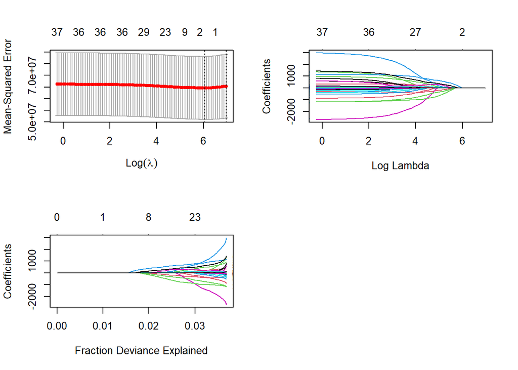

```
## $mse
## lambda.min
##   64278815
## attr(,"measure")
## [1] "Mean-Squared Error"
##
## $mae
## lambda.min
##   3708.151
## attr(,"measure")
## [1] "Mean Absolute Error"
```

```
## $AICc
## [1] -1584023783
##
## $BIC
## [1] -1584023777
```

```
## $AICc
## [1] 0
##
## $BIC
## [1] 0
```

Model Coefficients

|  | Est |
| --- | --- |
| (Intercept) | 4655.667 |
| BLUEBOOK | 0.079 |
| KIDSDRIV1 | 0.000 |
| AGE | 0.000 |
| HOMEKIDS1 | 0.000 |
| YOJ | 0.000 |
| INCOME | 0.000 |
| HOME_VAL | 0.000 |
| EDUCATIONBachelors | 0.000 |
| EDUCATIONHigh School | 0.000 |
| EDUCATIONMasters | 0.000 |
| EDUCATIONPhD | 0.000 |
| JOBClerical | 0.000 |
| JOBDoctor | 0.000 |
| JOBHome Maker | 0.000 |
| JOBLawyer | 0.000 |
| JOBManager | 0.000 |
| JOBProfessional | 0.000 |
| JOBStudent | 0.000 |
| JOBUnknown | 0.000 |
| TRAVTIME | 0.000 |
| TIF | 0.000 |
| CAR_TYPEPanel Truck | 0.000 |
| CAR_TYPEPickup | 0.000 |
| CAR_TYPESports Car | 0.000 |
| CAR_TYPESUV | 0.000 |
| CAR_TYPEVan | 0.000 |
| OLDCLAIM | 0.000 |
| CLM_FREQ | 0.000 |
| MVR_PTS | 0.000 |
| CAR_AGE | 0.000 |
| MALE1 | 0.000 |
| MARRIED1 | 0.000 |
| LIC_REVOKED1 | 0.000 |
| CAR_RED1 | 0.000 |
| PRIVATE_USE1 | 0.000 |
| SINGLE_PARENT1 | 0.000 |
| URBAN1 | 0.000 |

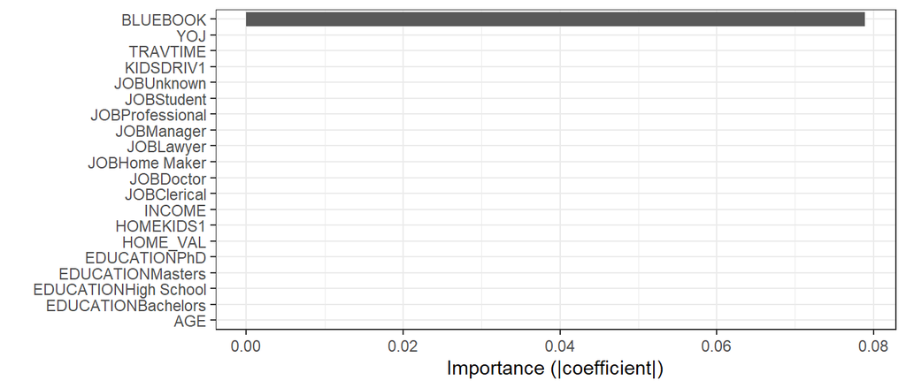

[figure not shown]